# Reproducible Research: Peer Assessment 1

This assignment makes use of data from a personal activity monitoring device. This device collects data at 5 minute intervals through out the day. The data consists of two months of data from an anonymous individual collected during the months of October and November, 2012 and include the number of steps taken in 5 minute intervals each day.

```r
library("knitr")
opts_chunk$set(echo=TRUE)
```

## Loading and preprocessing the data

```r
data <- read.csv("activity.csv");
```

Use **unzip(zipfile = “activity.zip”)** if necessary.

## What is mean total number of steps taken per day?

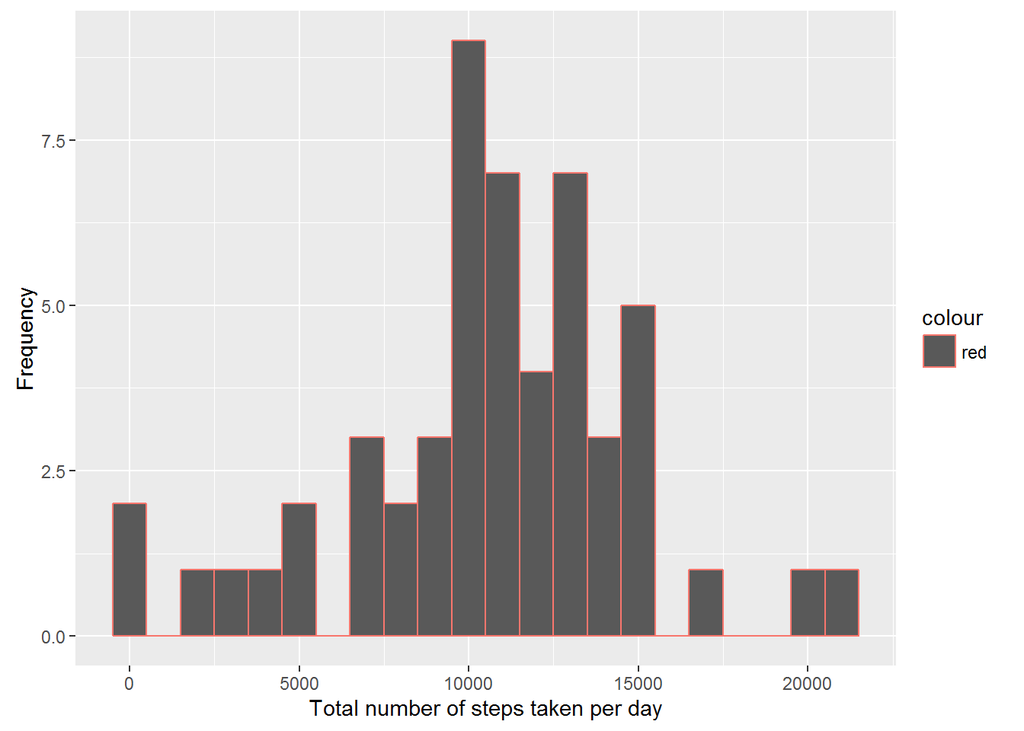

```r
library(ggplot2)
totalstepsmade <- tapply(data$steps, data$date, FUN=sum)
qplot(totalstepsmade, binwidth=1000, xlab="Total number of steps taken per day", ylab="Frequency", color="red")
```

```r
mean(totalstepsmade, na.rm=TRUE)
```

```
## [1] 10766.19
```

```r
median(totalstepsmade, na.rm=TRUE)
```

```
## [1] 10765
```

## What is the average daily activity pattern?

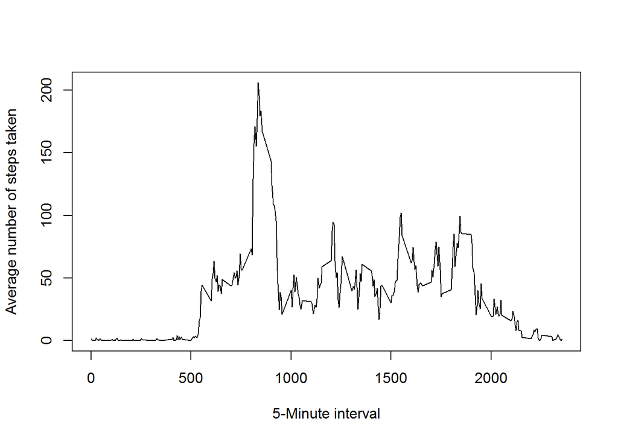

```r
library(ggplot2)
averagedailyact <- aggregate(x = list(steps = data$steps), by = list(interval = data$interval), FUN = mean, na.rm = TRUE)
plot(x=averagedailyact$interval, y=averagedailyact$steps, type="l", xlab="5-Minute interval", ylab="Average number of steps taken")
```

Which 5-minute interval, on average across all the days in the dataset, contains the maximum number of steps?

```r
averagedailyact[which.max(averagedailyact$steps), c(1,2)]
```

```
##     interval    steps
## 104      835 206.1698
```

The 5-minute time interval of the day with the highest average number of steps is from 8:35 AM to 8:40 AM, at 206.2 steps.